# Use purrr::map

GuohuanZhang

2022/7/18

## R Markdown

This is the 2nd R Markdown document of GuohuanZhang.

### This R Markdown document aims to show how to use purrr::map:

# 载入需要用到的包

```r
if(!require(pacman)){
  install.packages("pacman")
}
```

```r
pacman::p_load(tidyverse,  # 书写整洁的代码
               magrittr,   # 包含更多管道符——%<>%
               readxl,     # 读取 xlsx
               writexl,    # 输出 xlsx
               purrr,      # map
               tableone,   # 自动生成：表1.研究对象基本特征
               ggplot2,    # 画图
               gghalves,   # 小提琴图
               gridExtra,  # 多个图片排版
               broom,      # 整理模型结果
               psych)      # 相关矩阵图
```

# 读取数据

数据是我用rnorm()和sample()造出来的

可从我的github网页下载https://github.com/Thuoyuing/Thuoyuing.github.io/blob/main/element.xlsx

代码也可以下载https://github.com/Thuoyuing/Thuoyuing.github.io/blob/main/UseMap.R

```r
rm(list = ls())
read_xlsx("element.xlsx") -> data_raw
data_raw
```

```
## # A tibble: 300 x 14
##    ptbirth birthweight region   age weight height education smoking    As    Sr
##      <dbl>       <dbl> <chr>  <dbl>  <dbl>  <dbl>     <dbl>   <dbl> <dbl> <dbl>
##  1       0        3.33 North     22     55    180         1       0  24.0  62.1
##  2       0        3.50 North     25     54    162         3       1  19.4  66.8
##  3       0        3.36 North     30     56    158         1       1  30.0  66.1
##  4       0        3.56 North     29     61    180         1       1  22.2  66.8
##  5       0        3.44 South     20     65    153         1       0  26.3  76.7
##  6       0        3.52 South     23     76    170         3       0  28.1  63.3
##  7       0        3.58 South     22     54    156         2       1  23.6  58.4
##  8       0        3.40 South     30     67    167         3       0  26.2  58.2
##  9       0        3.19 North     24     70    176         3       1  25.8  59.1
## 10       0        3.45 South     24     67    164         1       0  25.5  58.8
## # ... with 290 more rows, and 4 more variables: B <dbl>, Al <dbl>, Th <dbl>,
## #   Ti <dbl>
```

今天用到：

ptbirth——早产

中间的人口学特征

后面的母体血元素浓度

# 数据的前处理

需要根据身高height和体重weight计算BMI

将将年龄、BMI转为等级

将分类变量转为因子变量

```r
data_raw %>%
  mutate(BMI = map2_dbl(weight,                # 计算 BMI，是二元函数
                        height,                # 使用 map2，让每一对weight与height
                        ~ .x/(.y/100)^2)) %>%  # 都按照这里的表达式计算
  mutate(age = case_when(age < 35 ~ 1,
                         age >= 35 ~ 2),       # 将年龄以35岁为界限，分为1，2
         BMI = case_when(BMI < 18.5 ~ 1,
                         BMI < 25 ~ 2,
                         BMI >= 25 ~ 3)) %>%   # 将BMI分为三个等级
  mutate(across(c(ptbirth,
                  age,
                  education,
                  smoking,
                  BMI),
                as.factor)) %>%                # 分类变量转为因子
  select(ptbirth,
         region,
         age,
         BMI,
         education,
         smoking,
         As:Ti) -> data
data
```

```
## # A tibble: 300 x 12
##    ptbirth region age   BMI   education smoking    As    Sr     B    Al    Th
##    <fct>   <chr>  <fct> <fct> <fct>     <fct>   <dbl> <dbl> <dbl> <dbl> <dbl>
##  1 0       North  1     1     1         0        24.0  62.1  27.3  14.5  14.5
##  2 0       North  1     2     3         1        19.4  66.8  27.3  14.7  15.5
##  3 0       North  1     2     1         1        30.0  66.1  28.7  13.0  15.4
##  4 0       North  1     2     1         1        22.2  66.8  32.0  14.2  16.7
##  5 0       South  1     3     1         0        26.3  76.7  24.0  12.8  17.3
##  6 0       South  1     3     3         0        28.1  63.3  27.3  14.9  13.4
##  7 0       South  1     2     2         1        23.6  58.4  36.8  16.8  15.2
##  8 0       South  1     2     3         0        26.2  58.2  24.2  15.8  14.9
##  9 0       North  1     2     3         1        25.8  59.1  30.9  15.1  13.6
## 10 0       South  1     2     1         0        25.5  58.8  37.9  14.0  15.0
## # ... with 290 more rows, and 1 more variable: Ti <dbl>
```

# 自动生成论文里的：表1.人群基本特征

```r
CreateTableOne(data = data,
               vars = c("region","age","BMI","education","smoking",
                        "As","Sr","B","Al","Th","Ti"),
               strata = "ptbirth",
               addOverall = T) %>%
  print(showAllLevels = T,
        nonnormal = c("As","Sr","B")) -> Table.one  # As,Sr,B使用非参数检验
```

```
##                    Stratified by ptbirth
##                     level Overall              0
##   n                         300                  150
##   region (%)        North   147 (49.0)            77 (51.3)
##                     South   153 (51.0)            73 (48.7)
##   age (%)           1       142 (47.3)           118 (78.7)
##                     2       158 (52.7)            32 (21.3)
##   BMI (%)           1        50 (16.7)            23 (15.3)
##                     2       147 (49.0)            78 (52.0)
##                     3       103 (34.3)            49 (32.7)
##   education (%)     1       107 (35.7)            53 (35.3)
##                     2        88 (29.3)            44 (29.3)
##                     3       105 (35.0)            53 (35.3)
##   smoking (%)       0       154 (51.3)            75 (50.0)
##                     1       146 (48.7)            75 (50.0)
##   As (median [IQR])       34.99 [27.26, 42.09] 27.37 [23.15, 33.11]
##   Sr (median [IQR])       50.03 [39.09, 62.41] 62.42 [54.04, 66.31]
##   B (median [IQR])        29.90 [27.02, 33.70] 30.38 [27.17, 33.56]
##   Al (mean (SD))          14.97 (1.07)         14.93 (1.10)
##   Th (mean (SD))          15.07 (1.04)         15.07 (1.09)
##   Ti (mean (SD))          50.24 (9.91)         49.68 (9.84)
##                    Stratified by ptbirth
##                     1                    p      test
##   n                   150
##   region (%)           70 (46.7)          0.488
##                        80 (53.3)
##   age (%)              24 (16.0)         <0.001
##                       126 (84.0)
##   BMI (%)              27 (18.0)          0.573
##                        69 (46.0)
##                        54 (36.0)
##   education (%)        54 (36.0)          0.991
##                        44 (29.3)
##                        52 (34.7)
##   smoking (%)          79 (52.7)          0.729
##                        71 (47.3)
##   As (median [IQR]) 41.76 [37.39, 46.53] <0.001 nonnorm
##   Sr (median [IQR]) 39.19 [34.16, 46.35] <0.001 nonnorm
##   B (median [IQR])  29.24 [26.81, 33.72]  0.434 nonnorm
##   Al (mean (SD))    15.02 (1.04)          0.511
##   Th (mean (SD))    15.06 (1.00)          0.878
##   Ti (mean (SD))    50.80 (9.98)          0.328
```

```r
# 把 Table.one 输出到 xlsx，就可以从excel文件直接粘贴到论文中了
# Table.one %>%
#   as.data.frame() %>%
#   write.csv("TableOne.csv")
```

# 观察元素浓度的分布特征——半小提琴图

使用ggplot画“半小提琴图”

```r
# 设置画图的主题，可以自己配置
theme(text = element_text(family = 'serif'),     # Times new roman字体
      plot.title = element_text(size='17',
                                hjust = 0.5),
      axis.title= element_text(size='15'),
      panel.background = element_rect(fill = 'white',
                                      color='black'),
      #panel.grid.major = element_line(color='grey',linetype = 2)
      panel.grid.major = element_blank()
      ) -> mytheme
# 设定画图的函数，方便后续用 map 批量作图
vioboxplotfun = function(element_name){
  data %>%
    select(ptbirth,
           region,
           element_name) %>%
    mutate(ptbirth = factor(ptbirth,
                                labels = c("No",
                                           "Yes"))) %>%
    rename("Conc." = element_name) %>%
    ggplot(aes(y = Conc.))+
    geom_half_violin(aes(fill = ptbirth),
                     size = 0.5,
                     trim=T,
                     side="l",
                     adjust = 1,
                     width = 0.55)+
    geom_half_dotplot(aes(fill = ptbirth,
                          color = NA),
                      alpha = 0.75,
                      method="histodot",
                      stackdir="up",
                      stackratio = 1.2,
                      position = position_nudge(x=0.06,
                                                y=0)) + #half dot plot
    geom_boxplot(width = 0.08)+
    scale_fill_manual(values = c("#33CCCC",
                                 "#FF6666",
                                 "#33CCCC",
                                 "#FF6666"))+
    scale_color_manual(values = c("#black",
                                  "#black"))+
    # scale_y_continuous(limits = c(8,125))+
    labs(title = element_name,
         y = "Conc. (ng/mL)")+
    facet_grid(region~ptbirth)+
    mytheme
}
# 选择需要作图的元素名称
data %>%
  select(As:Ti) %>%
  names() -> element_names
element_names
```

```
## [1] "As" "Sr" "B"  "Al" "Th" "Ti"
```

```
## Note: Using an external vector in selections is ambiguous.
## i Use `all_of(element_name)` instead of `element_name` to silence this message.
## i See <https://tidyselect.r-lib.org/reference/faq-external-vector.html>.
```

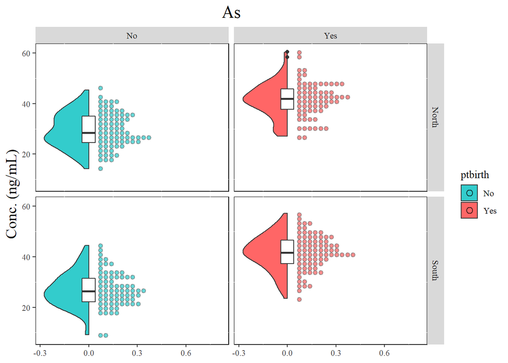

```r
# 我们先对一个元素——As画图
vioboxplotfun(element_names[1])
```

现在使用 map 对每一个元素批量画图

————map()对element_names中的每一个元素，都执行vioboxplotfun()

————marrangeGrob()图片排版

————ggsave将图片保存

```r
# map(element_names,                   # 对element_names中的每一个元素
#     vioboxplotfun) %>%               # 都执行vioboxplotfun
#   marrangeGrob(nrow = 2, ncol = 3)   # 将图片按2行3列排版
#   ggsave(file = 'Xplot_byregion.png',     # 保存图片
#          plot = .,
#          width = 15,      # 图片尺寸
#          height = 8,      # 图片尺寸
#          limitsize = FALSE)
```

# QQ图

同样的思路

```r
# 设定画图的函数，方便后续用 map 批量作图
QQplotfun = function(element_name){
  data %>%
    select(ptbirth,
           region,
           element_name) %>%
    mutate(ptbirth = factor(ptbirth,
                                labels = c("No",
                                           "Yes"))) %>%
    rename("Conc." = element_name) %>%
    ggplot(aes(sample = Conc.,
               color = ptbirth))+
    stat_qq()+
    stat_qq_line()+
    scale_fill_manual(values = c("#33CCCC",
                                 "#FF6666",
                                 "#33CCCC",
                                 "#FF6666"))+
    labs(title = element_name)+
    facet_grid(region~ptbirth)+
    mytheme
}
# 选择需要作图的元素名称
data %>%
  select(As:Ti) %>%
  names() -> element_names
element_names
```

```
## [1] "As" "Sr" "B"  "Al" "Th" "Ti"
```

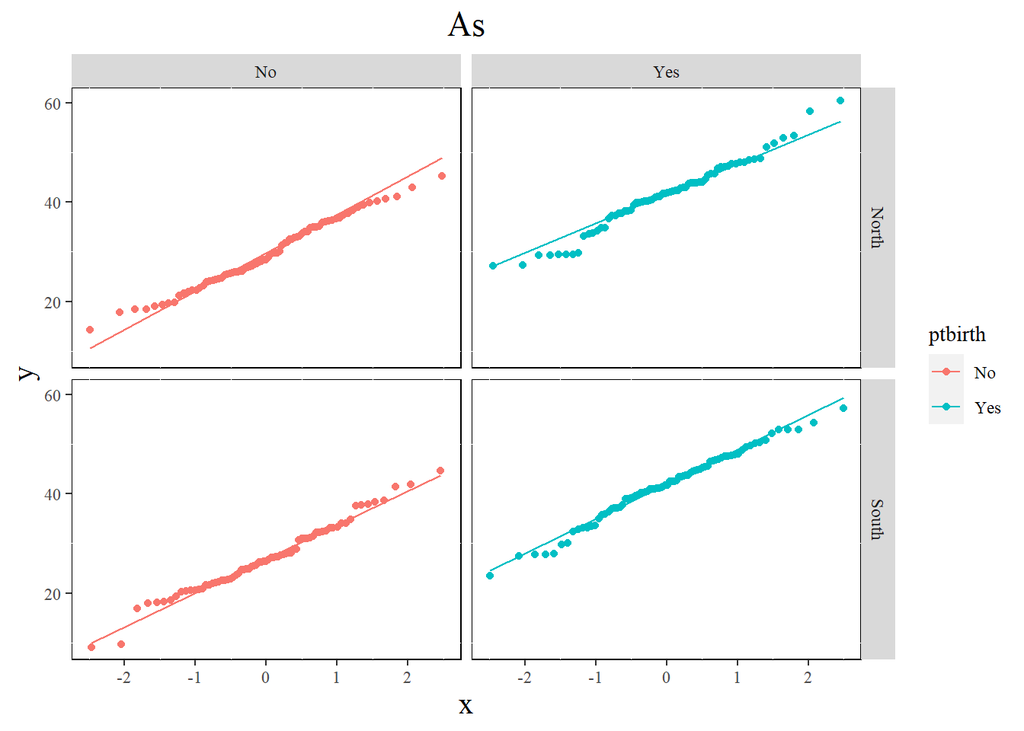

```r
# 先画一个图看看
QQplotfun(element_names[1])
```

现在使用 map 对每一个元素批量画图

————对element_names中的每一个元素，都执行QQplotfun()

```r
# map(element_names, QQplotfun) %>%
#   marrangeGrob(nrow = 2, ncol = 3) %>%
#   ggsave(file = 'XQQplot_byregion.png',
#          plot = .,
#          width = 15,
#          height = 8,
#          limitsize = FALSE)
```

# 相关矩阵图

```r
# 计算Corr matrix
psych::corr.test(data %>% select(As:Ti),
                 method = 'pearson',
                 adjust = 'none') -> corr.matrix
# 调色
col2 <- colorRampPalette(c( "#053061","#2166AC","#4393C3", "#92C5DE","#D1E5F0",
                            "#FFFFFF",
                            "#FDDBC7","#F4A582","#D6604D", "#B2182B", "#67001F" ))
```

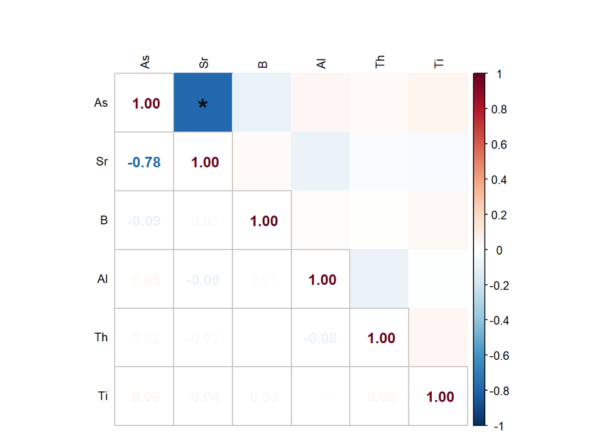

```r
#画图
corrplot::corrplot(corr.matrix$r,
                   method='color',
                   col=col2(200),
                   tl.cex=0.8,
                   tl.col='black',
                   p.mat=corr.matrix$p,
                   sig.level=0.05,
                   insig='label_sig',
                   pch.col='black',
                   pch.cex=2,mar=c(0,1,3,1))
corrplot::corrplot(corr.matrix$r,
                   add=TRUE,
                   type='lower',
                   method='number',
                   col=col2(200),
                   number.cex=1,
                   tl.pos='n',
                   cl.pos='n')
```

图中可以看到：Sr与As元素显著负相关，相关系数是 -0.78

# 批量检验

现在想要看早产组与正常组的母体血中各种元素浓度是否有差异

同样可以用map()进行批量检验，并将结果整齐地输出

写论文时直接把表格粘贴上去就好了，不用一个一个的填

思路很简单：

——每个元素占据一行

——使用map函数，对每一行执行同样的操作

——使用mutate函数，一列一列地把需要的结果加上去

### 第一步：先让每个元素的名称各占据一行（如下）

```r
# t.test
data %>%
  select(As:Ti) %>%
  names() %>%
  tibble(Variable=.)
```

```
## # A tibble: 6 x 1
##   Variable
##   <chr>
## 1 As
## 2 Sr
## 3 B
## 4 Al
## 5 Th
## 6 Ti
```

### 然后结合map与mutate，一列一列地把需要的内容加上去

```r
data %>%
  select(As:Ti) %>%
  names() %>%
  tibble(Variable=.) %>%
  mutate(df0 = map(Variable,        # 正常组的数据
                   ~ select(data %>% filter(ptbirth==0),
                            .)),
         df1 = map(Variable,        # 早产组的数据
                   ~ select(data %>% filter(ptbirth==1),
                            .)),
         mean0 = map_dbl(df0,       # 正常组浓度均值
                         ~ mean(as_vector(.))),
         mean1 = map_dbl(df1,       # 早产组浓度均值
                         ~ mean(as_vector(.))),
         ttest = map2(df0,          # t检验的结果以list的形式保存在ttest中
                      df1,
                      ~ t.test(.x,
                               .y)),
         t = map_dbl(ttest,         # 提取出t统计量
                     ~ .$statistic),
         p_value = map_dbl(ttest,   # 提取出p值
                           ~ .$p.value)) -> ttest.by.ptbirth
```

```
## Note: Using an external vector in selections is ambiguous.
## i Use `all_of(.)` instead of `.` to silence this message.
## i See <https://tidyselect.r-lib.org/reference/faq-external-vector.html>.
```

```r
ttest.by.ptbirth
```

```
## # A tibble: 6 x 8
##   Variable df0                df1      mean0 mean1 ttest         t  p_value
##   <chr>    <list>             <list>   <dbl> <dbl> <list>    <dbl>    <dbl>
## 1 As       <tibble [150 x 1]> <tibble>  28.2  41.5 <htest> -16.5   6.36e-44
## 2 Sr       <tibble [150 x 1]> <tibble>  60.7  40.2 <htest>  21.6   7.47e-63
## 3 B        <tibble [150 x 1]> <tibble>  30.3  29.9 <htest>   0.629 5.30e- 1
## 4 Al       <tibble [150 x 1]> <tibble>  14.9  15.0 <htest>  -0.659 5.11e- 1
## 5 Th       <tibble [150 x 1]> <tibble>  15.1  15.1 <htest>   0.154 8.78e- 1
## 6 Ti       <tibble [150 x 1]> <tibble>  49.7  50.8 <htest>  -0.981 3.28e- 1
```

东西比较杂，我们select需要的东西

```r
ttest.by.ptbirth %>%
  select(Variable,
         mean0,
         mean1,
         t,
         p_value)
```

```
## # A tibble: 6 x 5
##   Variable mean0 mean1       t  p_value
##   <chr>    <dbl> <dbl>   <dbl>    <dbl>
## 1 As        28.2  41.5 -16.5   6.36e-44
## 2 Sr        60.7  40.2  21.6   7.47e-63
## 3 B         30.3  29.9   0.629 5.30e- 1
## 4 Al        14.9  15.0  -0.659 5.11e- 1
## 5 Th        15.1  15.1   0.154 8.78e- 1
## 6 Ti        49.7  50.8  -0.981 3.28e- 1
```

后面加 %>% writexl::write_xlsx(“ttest.xlsx”) 就可以输出到xlsx文件

# 批量建模

对每一个元素，都用logistic回归分析它们与早产ptbirth的关系

思路与前面的批量检验一样

建模后使用broom包来整理模型的结果

### 不调整协变量的raw model

```r
# logit
data %>%
  select(As:Ti) %>%
  names() %>%
  tibble(Variable=.) %>%
  mutate(df = map(Variable,
                  ~ select(data,
                           ptbirth,
                           .)),
         model = map(df,
                     ~ glm(ptbirth~.,
                           family=binomial(link='logit'),
                           data=.,)),
         model_coefs = map(model, ~broom::tidy(.,conf.int = T, conf.level = 0.95))) %>%
  unnest(model_coefs) %>%
  select(Variable,term, estimate, conf.low, conf.high, p.value) %>%
  set_names(c('Model','Vars','beta','ci_l','ci_h','p')) -> logistic.raw
logistic.raw
```

```
## # A tibble: 12 x 6
##    Model Vars           beta     ci_l    ci_h        p
##    <chr> <chr>         <dbl>    <dbl>   <dbl>    <dbl>
##  1 As    (Intercept) -8.83   -10.9    -7.05   9.82e-20
##  2 As    As           0.252    0.203   0.310  1.95e-20
##  3 Sr    (Intercept) 13.0     10.3    16.2    4.86e-18
##  4 Sr    Sr          -0.257   -0.321  -0.205  2.74e-18
##  5 B     (Intercept)  0.450   -0.968   1.88   5.34e- 1
##  6 B     B           -0.0150  -0.0619  0.0315 5.29e- 1
##  7 Al    (Intercept) -1.07    -4.29    2.12   5.10e- 1
##  8 Al    Al           0.0717  -0.141   0.286  5.09e- 1
##  9 Th    (Intercept)  0.258   -3.03    3.55   8.78e- 1
## 10 Th    Th          -0.0171  -0.235   0.201  8.77e- 1
## 11 Ti    (Intercept) -0.578   -1.77    0.596  3.36e- 1
## 12 Ti    Ti           0.0115  -0.0114  0.0347 3.27e- 1
```

可以看到结果中还有截距的参数估计和假设检验结果

现在我们把截距的结果去掉，并把回归系数转换为OR值

```r
logistic.raw %>%
  filter(Model==Vars) %>%  # 筛选主变量的结果
  mutate(OR_raw = map_dbl(beta,
                          ~ exp(.)),
         low_raw = map_dbl(ci_l,
                           ~ exp(.)),
         high_raw = map_dbl(ci_h,
                            ~ exp(.))) %>%
  rename(p_raw = p) %>%
  select(Vars,
         OR_raw,
         low_raw,
         high_raw,
         p_raw) -> logistic.smry
logistic.smry
```

```
## # A tibble: 6 x 5
##   Vars  OR_raw low_raw high_raw    p_raw
##   <chr>  <dbl>   <dbl>    <dbl>    <dbl>
## 1 As     1.29    1.22     1.36  1.95e-20
## 2 Sr     0.773   0.725    0.815 2.74e-18
## 3 B      0.985   0.940    1.03  5.29e- 1
## 4 Al     1.07    0.869    1.33  5.09e- 1
## 5 Th     0.983   0.790    1.22  8.77e- 1
## 6 Ti     1.01    0.989    1.04  3.27e- 1
```

raw model 的结果就整理好了

### 调整协变量的 adj model

```r
data %>%
  select(As:Ti) %>%
  names() %>%
  tibble(Variable=.) %>%
  mutate(df = map(Variable,
                  ~ select(data,
                           ptbirth,
                           .,
                           region,  # 加入了协变量
                           age,
                           BMI,
                           education,
                           smoking)),
         models = map(df,
                     ~ glm(ptbirth~.,
                           family=binomial(link='logit'),
                           data=.,)),
         model_coefs = map(models, ~broom::tidy(.,conf.int = T, conf.level = 0.95))) %>%
  unnest(model_coefs) %>%
  select(Variable,term, estimate, conf.low, conf.high, p.value) %>%
  set_names(c('Model','Vars','adj_beta','adj_ci_l','adj_ci_h','adj_p')) -> logistic.adj

logistic.adj %>%
  filter(Model==Vars) %>%    # 筛选主变量的结果
  mutate(OR_adj = map_dbl(adj_beta,
                          ~ exp(.)),
         low_adj = map_dbl(adj_ci_l,
                           ~ exp(.)),
         high_adj = map_dbl(adj_ci_h,
                            ~ exp(.))) %>%
  rename(p_adj = adj_p) %>%
  select(Vars,
         OR_adj,
         low_adj,
         high_adj,
         p_adj) -> logistic.adj.smry
logistic.adj.smry
```

```
## # A tibble: 6 x 5
##   Vars  OR_adj low_adj high_adj    p_adj
##   <chr>  <dbl>   <dbl>    <dbl>    <dbl>
## 1 As     1.25    1.17     1.33  2.23e-11
## 2 Sr     0.756   0.699    0.808 3.49e-14
## 3 B      0.960   0.902    1.02  1.94e- 1
## 4 Al     1.05    0.791    1.39  7.44e- 1
## 5 Th     0.873   0.656    1.16  3.46e- 1
## 6 Ti     1.01    0.982    1.04  4.23e- 1
```

adj model 的结果也整理好了

## 森林图

将raw model和adj model结果合并，用于画森林图

```r
left_join(logistic.smry,
          logistic.adj.smry,
          by = "Vars") -> forest.plot.data
forest.plot.data
```

```
## # A tibble: 6 x 9
##   Vars  OR_raw low_raw high_raw    p_raw OR_adj low_adj high_adj    p_adj
##   <chr>  <dbl>   <dbl>    <dbl>    <dbl>  <dbl>   <dbl>    <dbl>    <dbl>
## 1 As     1.29    1.22     1.36  1.95e-20  1.25    1.17     1.33  2.23e-11
## 2 Sr     0.773   0.725    0.815 2.74e-18  0.756   0.699    0.808 3.49e-14
## 3 B      0.985   0.940    1.03  5.29e- 1  0.960   0.902    1.02  1.94e- 1
## 4 Al     1.07    0.869    1.33  5.09e- 1  1.05    0.791    1.39  7.44e- 1
## 5 Th     0.983   0.790    1.22  8.77e- 1  0.873   0.656    1.16  3.46e- 1
## 6 Ti     1.01    0.989    1.04  3.27e- 1  1.01    0.982    1.04  4.23e- 1
```

这样的数据格式还不方便用于画图

我们用pivot_longer把这个宽表转成长表

```r
forest.plot.data %<>%
  pivot_longer(-c(Vars),
               names_to = c(".value","Model"),
               names_sep = "_")
forest.plot.data
```

```
## # A tibble: 12 x 6
##    Vars  Model    OR   low  high        p
##    <chr> <chr> <dbl> <dbl> <dbl>    <dbl>
##  1 As    raw   1.29  1.22  1.36  1.95e-20
##  2 As    adj   1.25  1.17  1.33  2.23e-11
##  3 Sr    raw   0.773 0.725 0.815 2.74e-18
##  4 Sr    adj   0.756 0.699 0.808 3.49e-14
##  5 B     raw   0.985 0.940 1.03  5.29e- 1
##  6 B     adj   0.960 0.902 1.02  1.94e- 1
##  7 Al    raw   1.07  0.869 1.33  5.09e- 1
##  8 Al    adj   1.05  0.791 1.39  7.44e- 1
##  9 Th    raw   0.983 0.790 1.22  8.77e- 1
## 10 Th    adj   0.873 0.656 1.16  3.46e- 1
## 11 Ti    raw   1.01  0.989 1.04  3.27e- 1
## 12 Ti    adj   1.01  0.982 1.04  4.23e- 1
```

这样的格式，就可以用来画图了，可以仔细观察观察前后的格式区别

下面开始画图

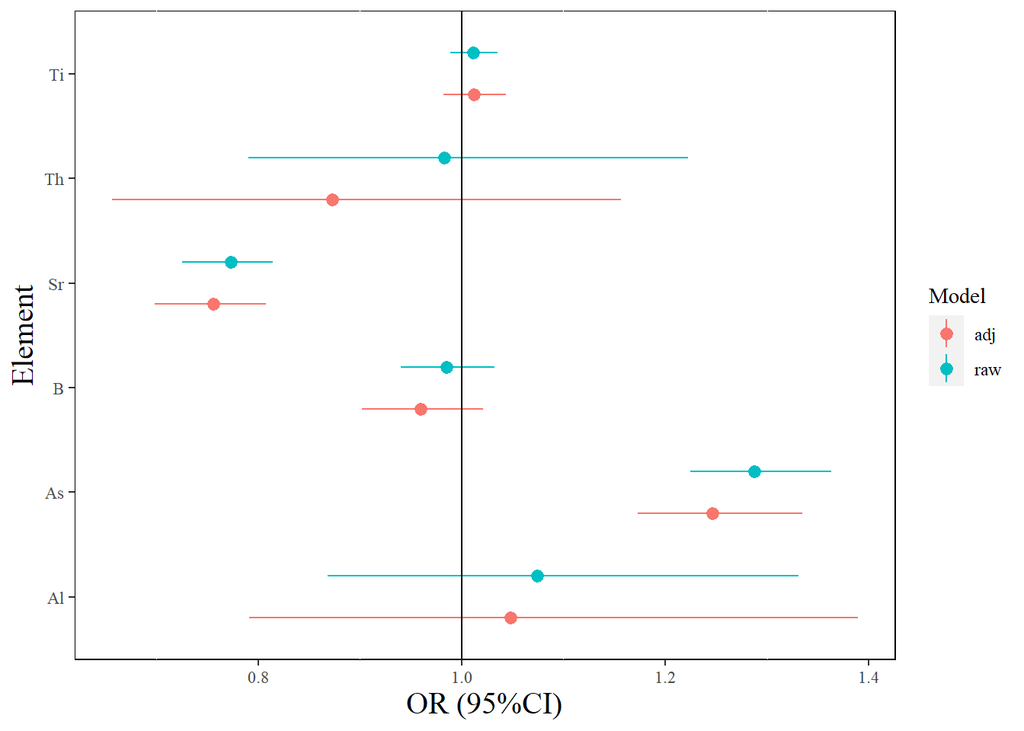

```r
forest.plot.data %>%
  ggplot(aes(x = Vars, y = OR , fill = Model, col = Model))+
  geom_point(position = position_dodge(0.8))+
  geom_pointrange(aes(ymax = high, ymin = low),
                  position = position_dodge(0.8), size = 0.5)+
  coord_flip()+
  geom_hline(aes(yintercept = 1))+
  labs(x = "Element", y = "OR (95%CI)")+
  mytheme+
  theme(strip.text = element_text(size = 14))
```

# Over————————————————————

特别鸣谢：

任梦圆师兄教我画的半小提琴图